# Topic Modeling

Unstructured Data Analytics

### 1. A Simple Topic Model

The `topicmodels` package provides us with a set of tools for topic modeling.

```r
library(dplyr)
library(ggplot2)
library(stringr)
library(tidyr)
library(tidytext)
library(topicmodels)
```

Let’s begin with a simple corpus of sentences (documents to us).

```r
corpus <-
  c(
    "Due to bad loans, the bank agreed to pay the fines.",
    "If you are late paying your bank loan, you will incur a fine.",
    "I heard that a new restaurant opened downtown.",
    "We had some good food at the new restaurant that just opened on Warwick street.",
    "How will you pay off the business loan for your restaurant?"
  )
```

The first thing we do is convert the corpus to a tibble.

```r
corpus <- tibble(document=1:5, text = corpus)
corpus
```

| document | text |
| --- | --- |
| 1 | Due to bad loans, the bank agreed to pay the fines. |
| 2 | If you are late paying your bank loan, you will incur a fine. |
| 3 | I heard that a new restaurant opened downtown. |
| 4 | We had some good food at the new restaurant that just opened on Warwick street. |
| 5 | How will you pay off the business loan for your restaurant? |

Then, we tokenize, remove stop words and convert it to a DTM (Document Term Matrix) using the `cast_dtm()` function from the `tidytext` package.

```r
corpus_dtm <- corpus %>%
  unnest_tokens(word, text) %>%
  anti_join(stop_words, by = "word") %>%
  count(document, word) %>%
  ungroup() %>%
  cast_dtm(document, word, n)
```

Note that we converted our data to a DTM because that is a requirement of the `LDA()` function from the `topicmodels` package. Once our data has been converted to a DTM, we can no longer preview it by simply calling it. We need to pass it to the `as.matrix()` function to preview it.

```r
as.matrix(corpus_dtm)
```

```
##     Terms
## Docs agreed bad bank due fines loans pay fine incur late loan paying downtown
##    1      1   1    1   1     1     1   1    0     0    0    0      0        0
##    2      0   0    1   0     0     0   0    1     1    1    1      1        0
##    3      0   0    0   0     0     0   0    0     0    0    0      0        1
##    4      0   0    0   0     0     0   0    0     0    0    0      0        0
##    5      0   0    0   0     0     0   1    0     0    0    1      0        0
##     Terms
## Docs heard restaurant food street warwick business
##    1     0          0    0      0       0        0
##    2     0          0    0      0       0        0
##    3     1          1    0      0       0        0
##    4     0          1    1      1       1        0
##    5     0          1    0      0       0        1
```

**Question:** What vector space model representation is this - binary, frequency count or weighted vector?

Now that we have our data in the format that we need it, we can use the `LDA()` function for topic modeling. The `LDA()` function takes several arguments:

1. `k` - The number of topics we want. We set this to `2`.
2. `method` - The method to use when fitting the model. We set this to `"Gibbs"` for Gibbs Sampling. The other supported method is `"VEM"`.
3. `alpha` - The dirichlet prior for the probability that a document belongs to a topic. We set this to `0.1`.
4. `delta` - The dirichlet prior for the probability distribution of words over topics. Set this to `0.1` as well.
5. `seed` - Random number generation seed. We set this to `1`.

```r
corpus_lda <- corpus_dtm %>%
  LDA(k = 2, method = "Gibbs", control = list(alpha = 0.1, delta = 0.1, seed = 1))

corpus_lda
```

```
## A LDA_Gibbs topic model with 2 topics.
```

With our model in place, let’s do some exploration and interpretation. The `LDA()` function returns two matrices. The first is called `beta` and it contains the probability of words belonging to a topic. The second matrix is called `gamma` and it contains the prevalence of topics within a document. To work with these matrices directly, we need to tidy them.

Let’s start with `beta`.

```r
corpus_topics <- corpus_lda %>%
  tidy(matrix = "beta")

corpus_topics
```

| topic | term | beta |
| --- | --- | --- |
| 1 | agreed | 0.009174312 |
| 2 | agreed | 0.065088757 |
| 1 | bad | 0.009174312 |
| 2 | bad | 0.065088757 |
| 1 | bank | 0.009174312 |
| 2 | bank | 0.124260355 |
| 1 | due | 0.009174312 |
| 2 | due | 0.065088757 |
| 1 | fines | 0.009174312 |
| 2 | fines | 0.065088757 |

[output cut: 28 more lines]

To see how good of a model we have, let’s take a look at the top 5 words for each topic.

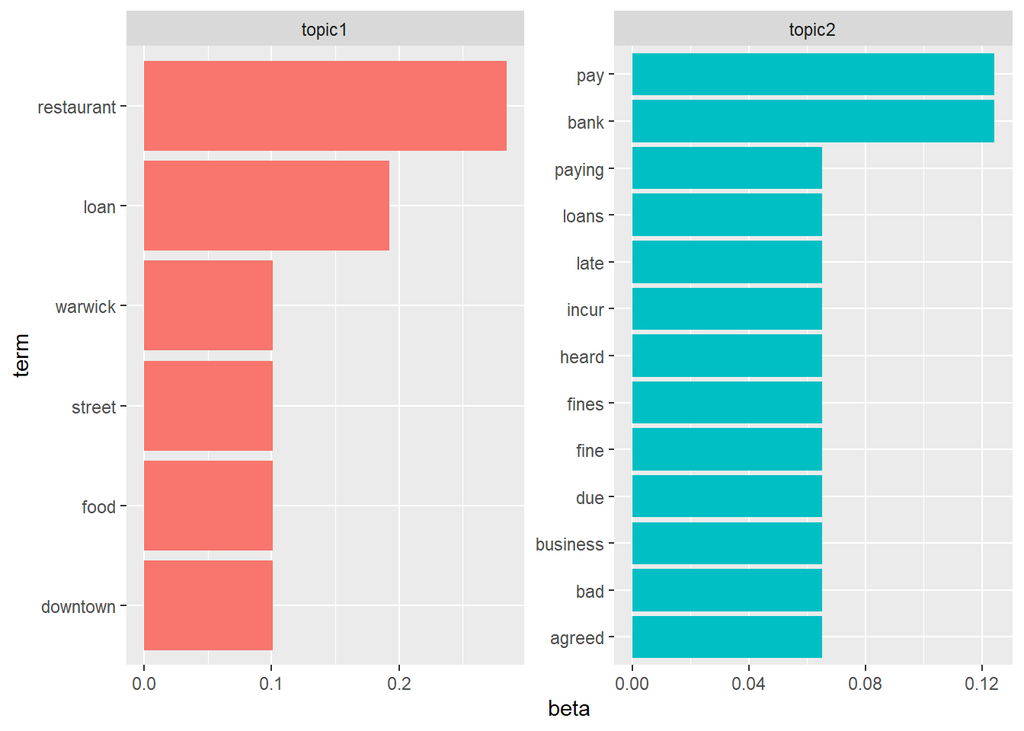

```r
corpus_topics %>%
  mutate(topic = str_c("topic", topic)) %>%
  group_by(topic) %>%
  top_n(5, beta) %>%
  ungroup() %>%
  arrange(topic, -beta) %>%
  mutate(term = reorder_within(term, beta, topic)) %>%
  ggplot(mapping = aes(x = term, y = beta, fill = factor(topic))) +
  geom_col(show.legend = FALSE) +
  facet_wrap(~ topic, scales = "free") +
  coord_flip() +
  scale_x_reordered()
```

**Question:** What labels would you assign to each topic?

Next, we look at `gamma`.

```r
corpus_documents <- corpus_lda %>%
  tidy(matrix = "gamma")

corpus_documents
```

| document | topic | gamma |
| --- | --- | --- |
| 1 | 1 | 0.01388889 |
| 2 | 1 | 0.17741935 |
| 3 | 1 | 0.65625000 |
| 4 | 1 | 0.97619048 |
| 5 | 1 | 0.50000000 |
| 1 | 2 | 0.98611111 |
| 2 | 2 | 0.82258065 |
| 3 | 2 | 0.34375000 |
| 4 | 2 | 0.02380952 |
| 5 | 2 | 0.50000000 |

Let’s reformat this in a way that’s easier to analyze.

```r
corpus_documents %>%
  mutate(topic = str_c("topic", topic)) %>%
  pivot_wider(names_from = topic, values_from = gamma) %>%
  mutate(document = as.integer(document)) %>%
  inner_join(corpus, by = "document") %>%
  arrange(document)
```

| document | topic1 | topic2 | text |
| --- | --- | --- | --- |
| 1 | 0.01388889 | 0.98611111 | Due to bad loans, the bank agreed to pay the fines. |
| 2 | 0.17741935 | 0.82258065 | If you are late paying your bank loan, you will incur a fine. |
| 3 | 0.65625000 | 0.34375000 | I heard that a new restaurant opened downtown. |
| 4 | 0.97619048 | 0.02380952 | We had some good food at the new restaurant that just opened on Warwick street. |
| 5 | 0.50000000 | 0.50000000 | How will you pay off the business loan for your restaurant? |

**Question:** How does this compare to what you expected?

### 2. Modeling the Topics from the Associated Press Dataset

To further illustrate topic modeling, let’s work with a larger dataset (the Associated Press practice dataset from 1992). The dataset is provided by the `tm` package. It contains 10473 terms across 2246 documents.

```r
library(tm)
```

To import the data into our environment, we pass the name of the dataset (“AssociatedPress”) to the `data()` function.

```r
data("AssociatedPress")
```

Next, we remove the stop words and convert our dataset into a DTM.

```r
#find the correct join colums by
# looking at the result of AssociatedPress %>% tidy()
# and the stop_words data
ap_dtm <- AssociatedPress %>%
  tidy() %>%
  anti_join(stop_words, by = c("term" = "word")) %>%
  cast_dtm(document = document, term = term, value = count)
```

Then we model the topics in the document.

```r
#pick numbers
ap_lda <- ap_dtm %>%
  LDA(k = 5, method = "Gibbs", control = list(alpha = 0.1, delta = 0.1, seed = 1))

ap_lda
```

```
## A LDA_Gibbs topic model with 5 topics.
```

#### Word-topic Probabilities

We can get the per-topic-per-word probabilities (`beta`)…

```r
ap_topics <- ap_lda %>%
  tidy(matrix = "beta")

ap_topics
```

| topic | term | beta |
| --- | --- | --- |
| 1 | adding | 2.390022e-04 |
| 2 | adding | 2.835680e-04 |
| 3 | adding | 1.065519e-04 |
| 4 | adding | 1.866035e-04 |
| 5 | adding | 9.150027e-05 |
| 1 | adult | 1.484486e-06 |
| 2 | adult | 2.618387e-04 |
| 3 | adult | 1.170900e-06 |
| 4 | adult | 1.681113e-06 |
| 5 | adult | 1.417610e-05 |

[output cut: 9990 more lines]

…and take a look at the terms that are most common within each topic.

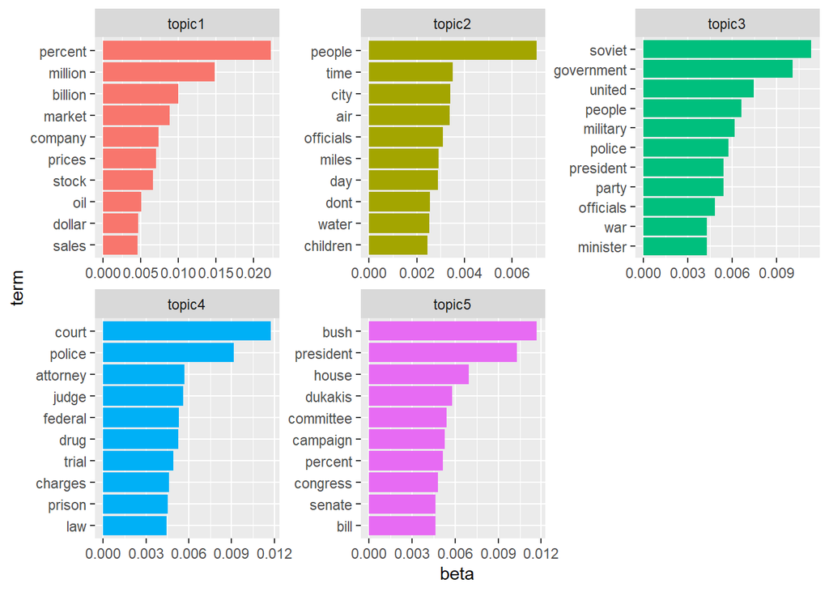

```r
ap_topics %>%
  mutate(topic = str_c("topic", topic)) %>%
  group_by(topic) %>%
  top_n(10, beta) %>%
  ungroup() %>%
  arrange(topic, -beta) %>%
  mutate(term = reorder_within(term, beta, topic)) %>%
  ggplot(mapping = aes(x = term, y = beta, fill = factor(topic))) +
  geom_col(show.legend = FALSE) +
  facet_wrap(~ topic, scales = "free") +
  coord_flip() +
  scale_x_reordered()
```

**Question:** What label would you assign to each topic?

#### Document-topic Probabilities

Now that we’ve seen the word probabilities by topic, let’s get the per-document-per-topic probabilities (`gamma`).

```r
ap_documents <- ap_lda %>%
  tidy(matrix = "gamma")

ap_documents
```

| document | topic | gamma |
| --- | --- | --- |
| 1 | 1 | 0.0048565121 |
| 2 | 1 | 0.1869848156 |
| 3 | 1 | 0.0005449591 |
| 4 | 1 | 0.0836565097 |
| 5 | 1 | 0.0020202020 |
| 6 | 1 | 0.0002758621 |
| 7 | 1 | 0.4297577855 |
| 8 | 1 | 0.0020202020 |
| 9 | 1 | 0.0153846154 |
| 10 | 1 | 0.0009216590 |

[output cut: 9990 more lines]

First, we look at the documents with the most dominance by a single topic.

```r
ap_documents %>%
  mutate(topic = str_c("topic", topic)) %>%
  pivot_wider(names_from = topic, values_from = gamma) %>%
  arrange(desc(abs(topic1 - topic2)))
```

| document | topic1 | topic2 | topic3 | topic4 | topic5 |
| --- | --- | --- | --- | --- | --- |
| 20 | 0.0003189793 | 0.9987240829 | 0.0003189793 | 0.0003189793 | 0.0003189793 |
| 1792 | 0.9986463621 | 0.0003384095 | 0.0003384095 | 0.0003384095 | 0.0003384095 |
| 697 | 0.9986277873 | 0.0003430532 | 0.0003430532 | 0.0003430532 | 0.0003430532 |
| 15 | 0.9984220907 | 0.0003944773 | 0.0003944773 | 0.0003944773 | 0.0003944773 |
| 1197 | 0.9983436853 | 0.0004140787 | 0.0004140787 | 0.0004140787 | 0.0004140787 |
| 61 | 0.9982869379 | 0.0004282655 | 0.0004282655 | 0.0004282655 | 0.0004282655 |
| 746 | 0.9982795699 | 0.0004301075 | 0.0004301075 | 0.0004301075 | 0.0004301075 |
| 35 | 0.0004395604 | 0.9982417582 | 0.0004395604 | 0.0004395604 | 0.0004395604 |
| 1491 | 0.9982339956 | 0.0004415011 | 0.0004415011 | 0.0004415011 | 0.0004415011 |
| 188 | 0.9981776765 | 0.0004555809 | 0.0004555809 | 0.0004555809 | 0.0004555809 |

[output cut: 2236 more lines]

Look for a document that is almost entirely from a single topic (the gamma value is close to 1). Let’s look at the most frequent words in that document.

```r
tidy(AssociatedPress) %>%
  filter(document == 20) %>%
  arrange(desc(count))
```

| document | term | count |
| --- | --- | --- |
| 20 | magellan | 11 |
| 20 | spacecraft | 11 |
| 20 | contact | 9 |
| 20 | pictures | 8 |
| 20 | earth | 6 |
| 20 | radar | 6 |
| 20 | scientists | 6 |
| 20 | venus | 6 |
| 20 | expected | 4 |
| 20 | lost | 4 |

[output cut: 210 more lines]

Find another document that is mostly from a different topic. Let’s take a look at it as well.

```r
tidy(AssociatedPress) %>%
  filter(document == 1792) %>%
  arrange(desc(count))
```

| document | term | count |
| --- | --- | --- |
| 1792 | late | 16 |
| 1792 | dollar | 11 |
| 1792 | rate | 9 |
| 1792 | bid | 7 |
| 1792 | fell | 7 |
| 1792 | monday | 7 |
| 1792 | new | 7 |
| 1792 | ounce | 7 |
| 1792 | rates | 7 |
| 1792 | gold | 6 |

[output cut: 167 more lines]

**Question:** Now that we see the words in some of these documents, do you still think our topic labels are good?

When we feel that we’re done, we can return the consensus topic for each document, by taking the topic with the highest gamma value.

```r
ap_documents %>%
  group_by(document) %>%
  top_n(1, gamma) %>%
  ungroup() %>%
  arrange(as.integer(document))
```

| document | topic | gamma |
| --- | --- | --- |
| 1 | 4 | 0.8128035 |
| 2 | 3 | 0.5470716 |
| 3 | 4 | 0.5128065 |
| 4 | 2 | 0.4105263 |
| 5 | 2 | 0.5878788 |
| 6 | 3 | 0.4885517 |
| 7 | 1 | 0.4297578 |
| 8 | 5 | 0.9919192 |
| 9 | 2 | 0.7846154 |
| 10 | 3 | 0.4709677 |

[output cut: 2246 more lines]

The consensus topic can now serve as the label for each of the documents in our corpus. However, remember that topic modeling is soft clustering. A document can belong to more than one topic.